# Njoroge et al 2021 Meta-analysis MS script

Dossa, Njoroge & Zuo

This document was last updated on Tue Jan 18 2022 05:57:41

# 1 Introduction

This work is based on conceptual figure

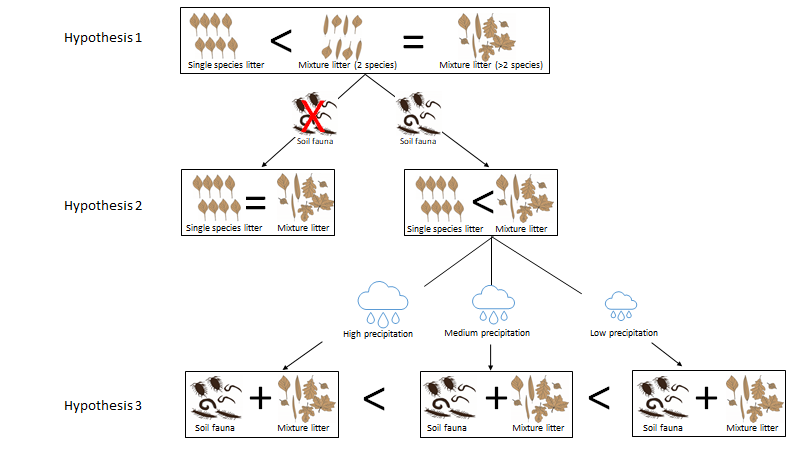

Hypothetical framework of this study

FIGURE 1 Hypothetical framework of this study. Litter mixture species richness and soil fauna are experimentally manipulated to depict their respective effect on litter decomposition (Hypotheses 1 and 2) and how precipitation levels influence those interactions. H1- Multiple species litter will have higher decomposition rate than the component single species litter in the mixture but this effect will soon saturate with an increase of litter species richness in mixture. H2- Inclusion of soil fauna will cause a change in the magnitude and direction of litter decomposition of multiple-species experiments, but not in single-species experiments. H3-With decreased precipitation, soil fauna will have a greater positive impact on the decomposition of litter mixtures, although we acknowledge a potential negative effect if dominant soil faunal taxa exert a net preferential feeding behaviour (Swan & Palmer, 2006b).

# 2 Analysis

## 2.1 Data input and exploration

### 2.1.1 Data input

```r
litmeta<-read.csv("litter_mixture.csv", header = TRUE, sep = ",", quote = "\"",
                dec = ".", fill = TRUE, comment.char = "")
(litmeta)
```

### 2.1.2 Data exploration

```r
dim(litmeta)
head(litmeta)
summary(litmeta)
colnames(litmeta)
```

```
## [1] 873  60
##   observation.number publication.number
## 1                  1                  1
## 2                  2                  1
## 3                  3                  1
## 4                  4                  1
## 5                  5                  1
## 6                  6                  1
##                                                                                                                       Title
## 1 Interaction between decomposing litter and soil fauna of the Betula ermanii forest floor of the Chanbai Mountains, China
## 2 Interaction between decomposing litter and soil fauna of the Betula ermanii forest floor of the Chanbai Mountains, China
## 3 Interaction between decomposing litter and soil fauna of the Betula ermanii forest floor of the Chanbai Mountains, China
## 4 Interaction between decomposing litter and soil fauna of the Betula ermanii forest floor of the Chanbai Mountains, China
## 5 Interaction between decomposing litter and soil fauna of the Betula ermanii forest floor of the Chanbai Mountains, China
## 6 Interaction between decomposing litter and soil fauna of the Betula ermanii forest floor of the Chanbai Mountains, China
##         Authors   Data_extracted_by Extraction_date Continent Country
## 1 Li et al 2014 Denis Mburu Njoroge      04/06/2020      Asia   China
## 2 Li et al 2014 Denis Mburu Njoroge      04/06/2020      Asia   China
## 3 Li et al 2014 Denis Mburu Njoroge      04/06/2020      Asia   China
## 4 Li et al 2014 Denis Mburu Njoroge      04/06/2020      Asia   China
## 5 Li et al 2014 Denis Mburu Njoroge      04/06/2020      Asia   China
## 6 Li et al 2014 Denis Mburu Njoroge      04/06/2020      Asia   China
##   year_of_experiment                  Site lat_decimals long_decimals eco_type
## 1               2011 Changbai Mountain (1)        42.03        128.03   Forest
## 2               2011 Changbai Mountain (1)        42.03        128.03   Forest
## 3               2011 Changbai Mountain (1)        42.03        128.03   Forest
## 4               2011 Changbai Mountain (1)        42.03        128.03   Forest
## 5               2011 Changbai Mountain (1)        42.03        128.03   Forest
## 6               2011 Changbai Mountain (1)        42.03        128.03   Forest
##   Annual_precip precipitation_levels Annual_temp  Regional_climate
## 1          1000                  low         6.1 subalpine climate
## 2          1000                  low         6.1 subalpine climate
## 3          1000                  low         6.1 subalpine climate
## 4          1000                  low         6.1 subalpine climate
## 5          1000                  low         6.1 subalpine climate
## 6          1000                  low         6.1 subalpine climate
##   climatic_region SOM Soil.C.. Soil.N. Soil.C.N.ratio Soil.pH
## 1       Temperate N/A     12.3    0.57            N/A    4.96
## 2       Temperate N/A     12.3    0.57            N/A    4.96
## 3       Temperate N/A     12.3    0.57            N/A    4.96
```

[output cut: 162 more lines]

```
## [16] "Annual_temp"          "Regional_climate"     "climatic_region"
## [19] "SOM"                  "Soil.C.."             "Soil.N."
## [22] "Soil.C.N.ratio"       "Soil.pH"              "litterbags_size_cm2"
## [25] "Fauna_available"      "Top_mesh_size"        "Fauna_group"
## [28] "Bottom_mesh_size"     "Burial_location"      "Time_Days"
## [31] "Duration_period"      "spc_abbr"             "Litter_type"
## [34] "Drying_method"        "Oven_temp_C"          "Litter_size"
## [37] "sp_div_in_mixture"    "species_richness"     "propotions"
## [40] "Mixture_mass_ratio"   "n_expected"           "n_observed"
## [43] "Lit_Car"              "Lit_Nit"              "Lit_Pho"
## [46] "Lit_Lig"              "Lit_Car_Nit_ratio"    "Lit_Lig_Nit_ratio"
## [49] "expected_decay_k"     "observed_decay_k"     "initial_weight_g"
## [52] "Final_weight_g"       "m_expected"           "sd_expected"
## [55] "m_observed"           "sd_observed"          "obs_per_day"
## [58] "exp_per_day"          "sd_obsv_per_day"      "sd_exp_per_day"
```

#### 2.1.2.1 Studies geograpical distribution

Before plotting the distribution of the studies site, let’s load the libraries needed to do so.

```r
library(sf)
library(rnaturalearth)
library(rnaturalearthdata)
library(sp)
library(rworldmap)
library(rgeos)
library(ggspatial)
library(ggmap)
```

```r
library(OpenStreetMap)
library(ggplot2)
library(rnaturalearth)
library(rnaturalearthdata)
library(maps)
```

Let’s now plot the globe map.

```r
world_map <- map_data("world")
```

Then, we need to create a base plot with gpplot2 package.

```r
library(ggplot2)
p <- ggplot() + coord_fixed() + xlab("") + ylab("")
```

Add map to base plot

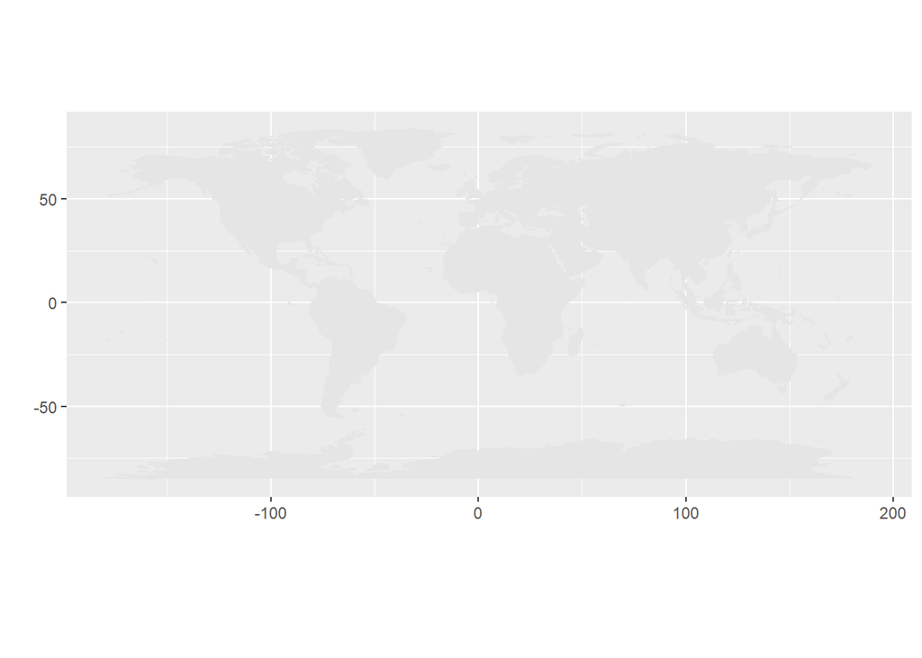

```r
base_world_messy <- p + geom_polygon(data=world_map, aes(x=long, y=lat, group=group),
                                     colour="gray90", fill="gray90")
base_world_messy
```

Strip the map down so it looks super clean and beautiful

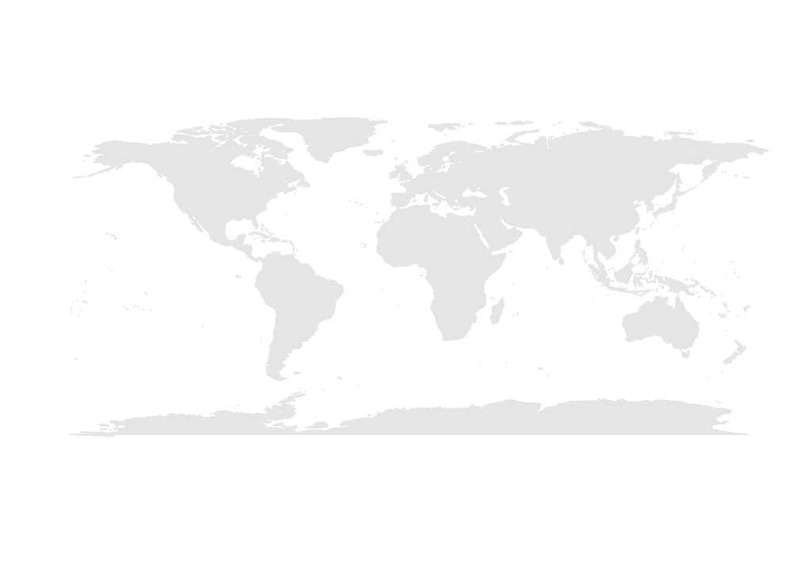

```r
cleanup <-
  theme(panel.grid.major = element_blank(), panel.grid.minor = element_blank(),
        panel.background = element_rect(fill = 'white', colour = 'white'),
        axis.line = element_line(colour = "white"), legend.position="none",
        axis.ticks=element_blank(), axis.text.x=element_blank(),
        axis.text.y=element_blank())
base_world <- base_world_messy + cleanup
base_world
```

Add simple data points to map. We need to first know the unique points as studies has replicates.

```r
names(litmeta)
unique(litmeta$Country)
unique(litmeta$Site)
unique(litmeta$publication.number)
```

Construct a dataframe with a summary statistics which is the number of samples per observation

```r
library(plyr)##
df_site <- ddply(litmeta, c("Country", "Site","long_decimals","lat_decimals", "climatic_region", "eco_type"), summarise,
                 N= length(m_observed))
df_site
```

Now, you the above information, to built a customized map that shows studies geographical distribution

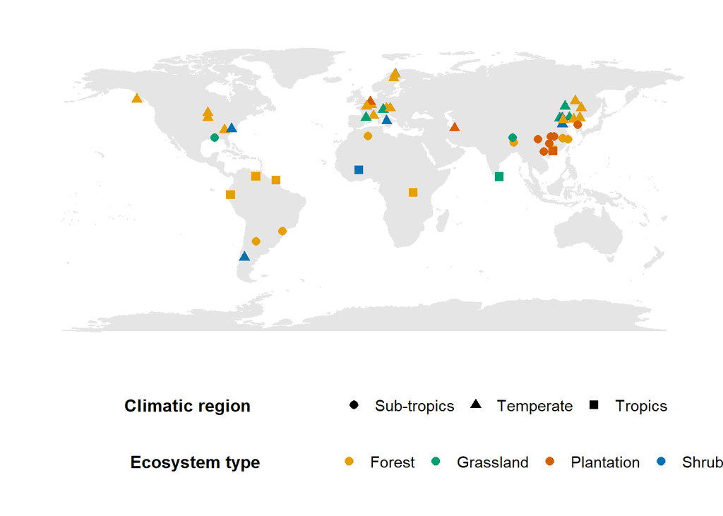

```r
p<- base_world +
  geom_point(data=df_site,  aes(x=long_decimals, y=lat_decimals, colour=eco_type, shape= climatic_region),
             size=2.5, alpha=I(1.0)) +
  scale_colour_manual(values=c("#E69F00", "#009E73", "#D55E00", "#0072B2"))
p<- p+ theme(legend.position="bottom", legend.box = "vertical") +
  labs(shape="Climatic region                 ", colour="                   Ecosystem type              ")+
  theme(legend.justification = "left")+
  theme(legend.title.align = -2) + theme(legend.background = element_rect(fill = "white"),
                                         legend.key = element_rect(fill = "white", color = NA))+
  guides(color=guide_legend(title.hjust=0.5))
figure2<- p+theme(legend.title = element_text(face = "bold",size = 12))+ theme(legend.text=element_text(size=11))
figure2
```

#### 2.1.2.2 Exclusion of negative mass loss points

Going back to the data exploration, some values are negative in m_expected and in m_observed. We confirmed with relevant authors about the accuracy of these data. The authors confirmed their accuracy, thus we deleted them from our next analysis.

```r
dim(litmeta)
litmeta<-litmeta[!litmeta$m_expected<0,]
dim(litmeta)
litmeta<-litmeta[!litmeta$m_observed<0,]
dim(litmeta)
```

```
## [1] 873  60
## [1] 868  60
## [1] 867  60
```

Check with summary and see if the negative values were removed.

```r
summary(litmeta)
colnames(litmeta)
```

Read some columns as numeric.

#### 2.1.2.3 Convert to numeric variables

```r
litmeta$Lit_Car<-as.numeric(litmeta$Lit_Car)
litmeta$Lit_Pho<-as.numeric(litmeta$Lit_Pho)
litmeta$Lit_Nit<-as.numeric(litmeta$Lit_Nit)
litmeta$Lit_Lig<-as.numeric(litmeta$Lit_Lig)
litmeta$Lit_Car_Nit_ratio<-as.numeric(litmeta$Lit_Car_Nit_ratio)
litmeta$Lit_Lig_Nit_ratio<-as.numeric(litmeta$Lit_Lig_Nit_ratio)
litmeta$expected_decay_k<-as.numeric(litmeta$expected_decay_k)
litmeta$observed_decay_k<-as.numeric(litmeta$observed_decay_k)
litmeta$Annual_precip<-as.numeric(litmeta$Annual_precip)
litmeta$Time_Days<-as.numeric(litmeta$Time_Days)
```

Here we subset the columns that we need. The first 6 columns are not useful for subsequent analyses.

```r
litmeta<-as.data.frame(litmeta[,7:dim(litmeta)[2]])
str(litmeta)
summary(litmeta)
colnames(litmeta)
```

#### 2.1.2.4 Convert some variables to factors

Read some variables as a factor.

```r
litmeta$Continent<-as.factor(litmeta$Continent)
litmeta$Country<-as.factor(litmeta$Country)
levels(litmeta$Country)
litmeta$Fauna_available<-as.factor(litmeta$Fauna_available)
levels(litmeta$Fauna_available)
litmeta$Litter_type<-as.factor(litmeta$Litter_type)
levels(litmeta$Litter_type)
litmeta$Site <-as.factor(litmeta$Site)
levels(litmeta$Site)
litmeta$eco_type <-as.factor(litmeta$eco_type)
levels(litmeta$eco_type)
litmeta$precipitation_levels <-as.factor(litmeta$precipitation_levels)
levels(litmeta$precipitation_levels)
litmeta$climatic_region<-as.factor(litmeta$climatic_region)
litmeta$Fauna_group<-as.factor(litmeta$Fauna_group)
```

## 2.2 Computations of response ratio

We calculated the response ratio (log transformed ratio of means) with the *escalc()* in the package metafor.

```r
library(metafor)
litmeta
lnRR <- escalc(measure = "ROM", n1i = n_expected, n2i = n_observed, m1i = m_expected,
               m2i = m_observed, sd1i = sd_expected, sd2i = sd_observed, append=FALSE,data=litmeta)
summary(lnRR)
dim(lnRR)
```

Add the effect sizes to the original data set with cbind or bind_cols from the package dplyr

```r
library(dplyr)
litmeta <- bind_cols(litmeta, lnRR)
dim(litmeta)
head(litmeta)
min(litmeta[,ncol(litmeta)])
max(litmeta[,ncol(litmeta)])
```

## 2.3 Create a random effect model.

```r
random_m <- rma(yi = yi, vi = vi, method = "REML", data = litmeta)
summary(random_m)
```

```
##
## Random-Effects Model (k = 867; tau^2 estimator: REML)
##
##    logLik   deviance        AIC        BIC       AICc
##   82.8154  -165.6309  -161.6309  -152.1031  -161.6170
##
## tau^2 (estimated amount of total heterogeneity): 0.0224 (SE = 0.0015)
## tau (square root of estimated tau^2 value):      0.1498
## I^2 (total heterogeneity / total variability):   100.00%
## H^2 (total variability / sampling variability):  43424.24
##
## Test for Heterogeneity:
## Q(df = 866) = 56179610.0593, p-val < .0001
##
## Model Results:
##
## estimate      se     zval    pval    ci.lb   ci.ub
##  -0.0061  0.0064  -0.9434  0.3455  -0.0187  0.0066
##
## ---
## Signif. codes:  0 '***' 0.001 '**' 0.01 '*' 0.05 '.' 0.1 ' ' 1
```

## 2.4 Publication bias

We checked publication bias by using funnel plot method

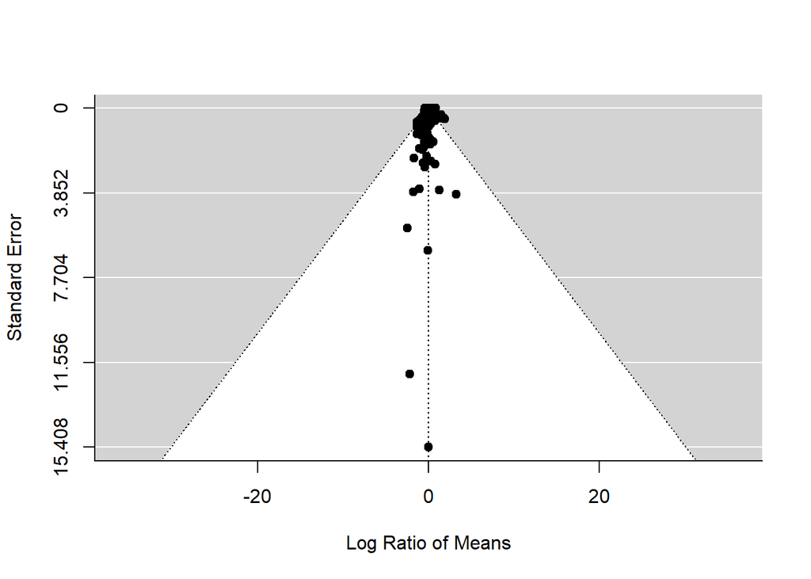

```r
funnel(random_m)
```

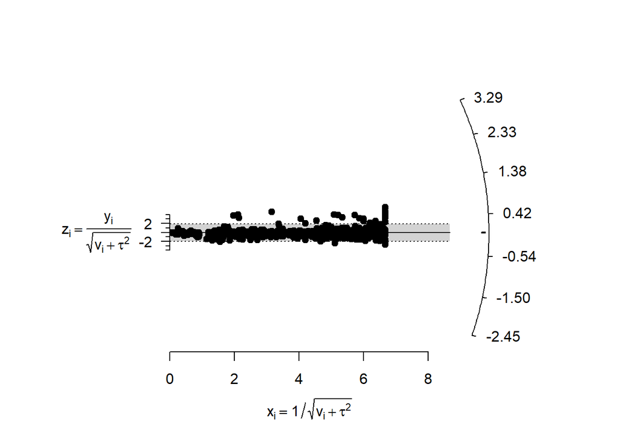

```r
radial(random_m)
```

we can also use contour funnel plot as this another way to check for publication bias. Save this funnel plot as supplementary material (Figure S1)

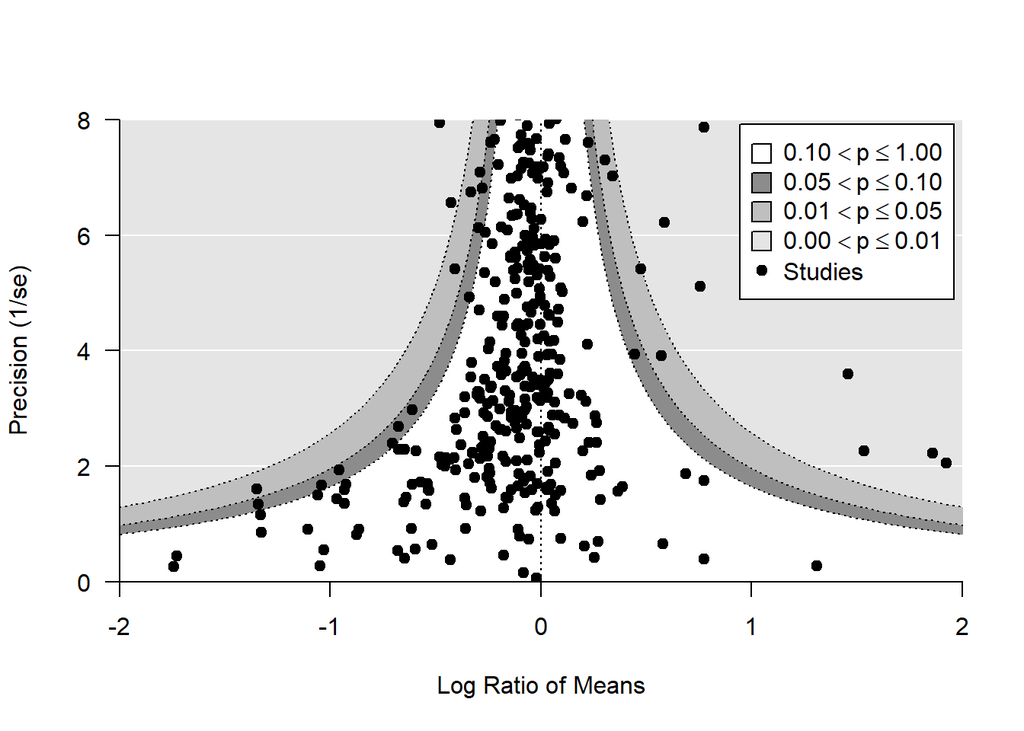

```r
#path<-getwd()
funnel(litmeta$yi, litmeta$vi, yaxis="seinv",
       xlim=c(-2,2), ylim=c(.00001,8), xaxs="i", yaxs="i", las=1,
       level=c(.10, .05, .01), shade=c("white", "gray55", "gray75"),
       legend=TRUE, back="gray90", ylab="Precision (1/se)")
```

```r
#ggsave(filename="funnel.png", plot=contour, device="png",
#       path=path, height=6, width=8, units="in", dpi=500)
```

## 2.5 Rosenberg fail safe number

```r
fsn(yi, vi, data=litmeta, type="Rosenberg")
fsn(yi, vi, data=litmeta, type="Rosenthal")
```

## 2.6 Statistical analysis (Hypothesis H1)

Let’s fit random-effects models to some subsets.

### 2.6.1 Create data subsets

#### 2.6.1.1 Estimated effect size based on the fauna status

We used the function *rma()* from metafor to estimate the effect size by fitting moderators.

```r
res.m <- rma(yi, vi, data = litmeta, subset = (Fauna_available=="present"))
res.n <- rma(yi, vi, data = litmeta, subset = (Fauna_available=="absent"))
random_m <- rma(yi = yi, vi = vi, method = "REML", data = litmeta)
res.m
res.n
```

```
##
## Random-Effects Model (k = 274; tau^2 estimator: REML)
##
## tau^2 (estimated amount of total heterogeneity): 0.0466 (SE = 0.0046)
## tau (square root of estimated tau^2 value):      0.2159
## I^2 (total heterogeneity / total variability):   100.00%
## H^2 (total variability / sampling variability):  282599.00
##
## Test for Heterogeneity:
## Q(df = 273) = 49346403.1852, p-val < .0001
##
## Model Results:
##
## estimate      se    zval    pval   ci.lb   ci.ub
##   0.0376  0.0142  2.6494  0.0081  0.0098  0.0655  **
##
## ---
## Signif. codes:  0 '***' 0.001 '**' 0.01 '*' 0.05 '.' 0.1 ' ' 1
##
##
## Random-Effects Model (k = 593; tau^2 estimator: REML)
##
## tau^2 (estimated amount of total heterogeneity): 0.0055 (SE = 0.0006)
## tau (square root of estimated tau^2 value):      0.0740
## I^2 (total heterogeneity / total variability):   99.32%
## H^2 (total variability / sampling variability):  146.49
##
## Test for Heterogeneity:
## Q(df = 592) = 40787.0377, p-val < .0001
##
## Model Results:
##
## estimate      se     zval    pval    ci.lb    ci.ub
##  -0.0225  0.0048  -4.6978  <.0001  -0.0319  -0.0131  ***
##
## ---
## Signif. codes:  0 '***' 0.001 '**' 0.01 '*' 0.05 '.' 0.1 ' ' 1
```

##### 2.6.1.1.1 Forest plot

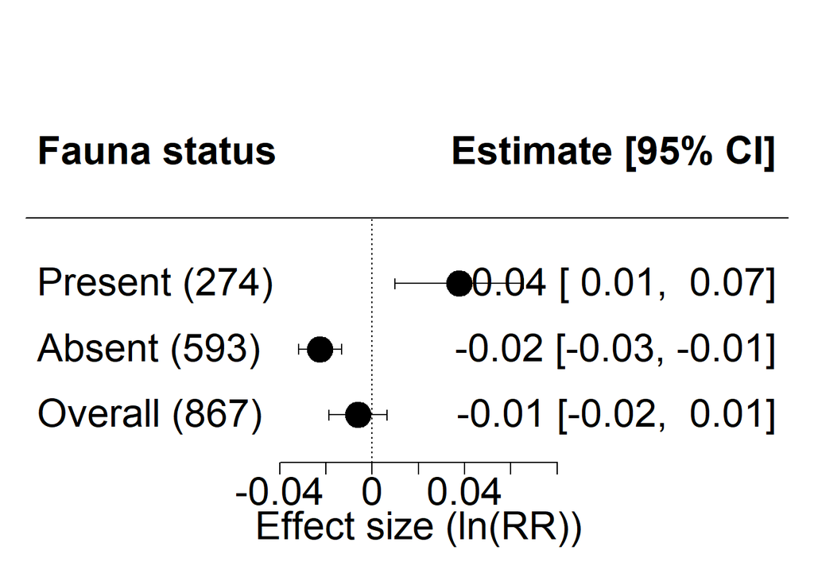

```r
estimates <- c(coef(res.m), coef(res.n), coef(random_m))
variances <- c(vcov(res.m), vcov(res.n), vcov(random_m))
labels <- c("Present (274)", "Absent (593)", "Overall (867)")
forest(estimates, variances, slab=labels,col="black", header = "Fauna status",pch = 19, cex=2,xlab = "Effect size (ln(RR))", psize = 1.5)
```

We can also use ggplot2 package to plot the above forest plot. This gives more flexibility in graph plotting and leads to better visual impact (Figure 3)

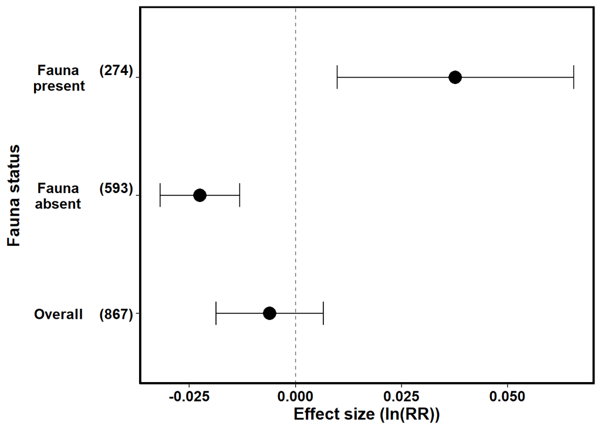

```r
dat <- data.frame(
  label = c("Fauna     (274)
  present            ", "Fauna     (593)
  absent             ", "Overall    (867)"),
  point_est = c(0.0376,-0.0225, -0.0061),
  lb_ci = c(0.0098,-0.0319 , -0.0187),
  ub_ci = c(0.0655,-0.0131, 0.0066),
  group = c(1,2,3))
#require(dplyr)
#dat<- dat %>% mutate(label = factor(label),
 #             label = factor(label, levels = rev(levels(label))))
dat$label <- factor(dat$label, levels = dat$label)
plot1 <- ggplot(dat, aes(x=point_est, y=label))  +
  geom_point(size=5) + scale_y_discrete(limits = rev(levels(dat$label)))+ geom_vline(xintercept=0, color="black", linetype="dashed", alpha=.5) +
  geom_errorbarh(aes(xmin=lb_ci, xmax=ub_ci), height=.2) + theme(legend.position="none") +
  ylab("Fauna status") + xlab("Effect size (ln(RR))") + theme(text = element_text(size = 14,face="bold"), panel.background = element_blank(),
                                                   panel.grid.major = element_blank(),
                                                   panel.grid.minor = element_blank(),
                                                   axis.line = element_line(colour = "black"),
                                                   panel.border = element_rect(colour = "black", fill=NA, size=1.5)) +  theme(axis.text = element_text(family = "palatino", colour = "black", size = (12)))
plot1
```

#### 2.6.1.2 Estimated effect size based on the climatic regions

```r
res.temperate <- rma(yi, vi, data=litmeta, subset=climatic_region=="Temperate")
res.tropics <- rma(yi, vi, data=litmeta, subset=climatic_region=="Tropics")
res.subtropics <- rma(yi, vi, data=litmeta, subset=climatic_region=="Sub-tropics")
res.temperate
res.tropics
res.subtropics
```

```
##
## Random-Effects Model (k = 504; tau^2 estimator: REML)
##
## tau^2 (estimated amount of total heterogeneity): 0.0078 (SE = 0.0008)
## tau (square root of estimated tau^2 value):      0.0881
## I^2 (total heterogeneity / total variability):   99.69%
## H^2 (total variability / sampling variability):  321.03
##
## Test for Heterogeneity:
## Q(df = 503) = 904792.7749, p-val < .0001
##
## Model Results:
##
## estimate      se     zval    pval    ci.lb    ci.ub
##  -0.0359  0.0056  -6.3569  <.0001  -0.0469  -0.0248  ***
##
## ---
## Signif. codes:  0 '***' 0.001 '**' 0.01 '*' 0.05 '.' 0.1 ' ' 1
##
##
## Random-Effects Model (k = 120; tau^2 estimator: REML)
##
## tau^2 (estimated amount of total heterogeneity): 0.0340 (SE = 0.0049)
## tau (square root of estimated tau^2 value):      0.1845
## I^2 (total heterogeneity / total variability):   99.89%
## H^2 (total variability / sampling variability):  871.73
##
## Test for Heterogeneity:
## Q(df = 119) = 9309.8100, p-val < .0001
##
## Model Results:
##
## estimate      se    zval    pval   ci.lb   ci.ub
##   0.0523  0.0181  2.8910  0.0038  0.0168  0.0878  **
##
## ---
## Signif. codes:  0 '***' 0.001 '**' 0.01 '*' 0.05 '.' 0.1 ' ' 1
##
##
## Random-Effects Model (k = 243; tau^2 estimator: REML)
##
## tau^2 (estimated amount of total heterogeneity): 0.0392 (SE = 0.0051)
## tau (square root of estimated tau^2 value):      0.1979
## I^2 (total heterogeneity / total variability):   100.00%
## H^2 (total variability / sampling variability):  264013.61
##
## Test for Heterogeneity:
## Q(df = 242) = 35964103.8952, p-val < .0001
##
## Model Results:
##
## estimate      se    zval    pval    ci.lb   ci.ub
##   0.0193  0.0161  1.1939  0.2325  -0.0124  0.0509
##
## ---
## Signif. codes:  0 '***' 0.001 '**' 0.01 '*' 0.05 '.' 0.1 ' ' 1
```

##### 2.6.1.2.1 Forest plot for climatic regions

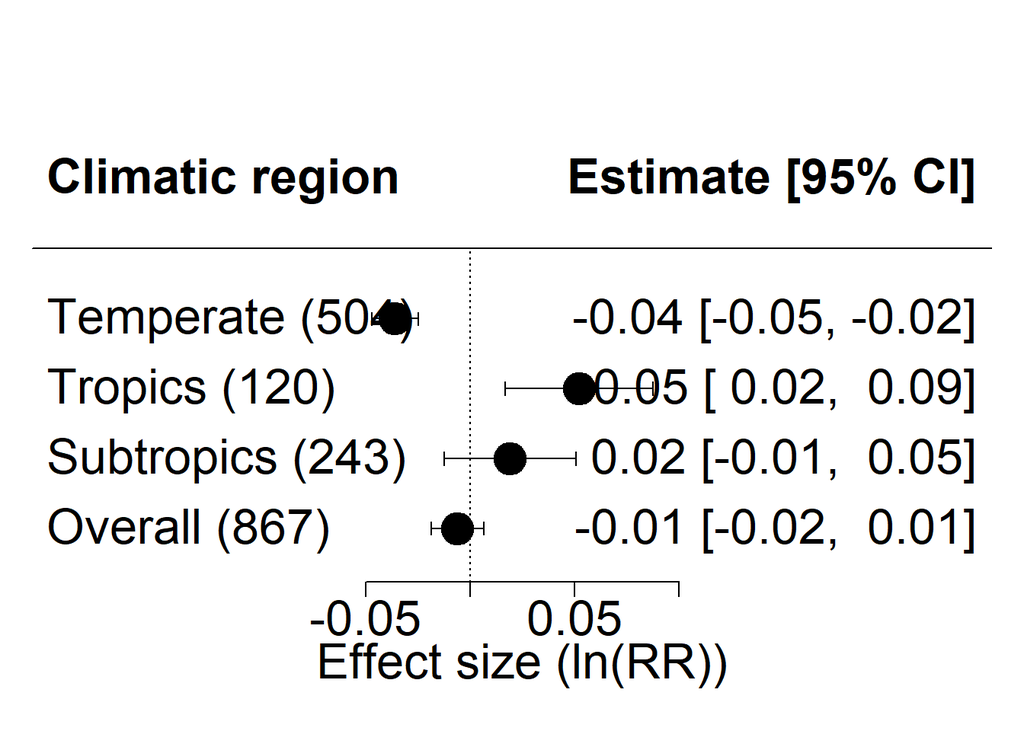

```r
estimates <- c(coef(res.temperate), coef(res.tropics), coef(res.subtropics),coef(random_m))
variances <- c(vcov(res.temperate), vcov(res.tropics), vcov(res.subtropics),vcov(random_m))
labels <- c("Temperate (504)", "Tropics (120)", "Subtropics (243)","Overall (867)")
forest(estimates, variances, slab=labels, col="black", header = "Climatic region",xlab='Effect size (ln(RR))',pch=19, cex=2, psize = 1.5)
```

Plot the above forest plot using ggplot2

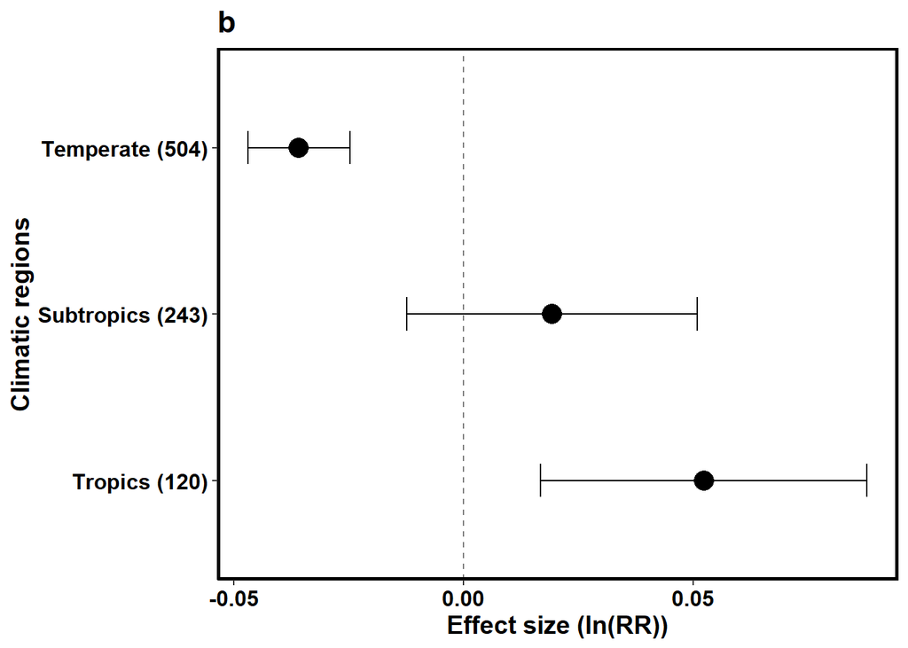

```r
dat7 <- data.frame(
  label = c("Temperate (504)", "Subtropics (243)", "Tropics (120)"),
  point_est = c(-0.0359 ,0.0193, 0.0523),
  lb_ci = c(-0.0469,-0.0124,0.0168),
  ub_ci = c( -0.0248  ,0.0509,  0.0878 ))
dat7$label <- factor(dat7$label, levels = dat7$label)
plot7 <- ggplot(dat7, aes(x=point_est, y=label)) +
  geom_point(size=5) + scale_y_discrete(limits = rev(levels(dat7$label))) + geom_vline(xintercept=0, color="black", linetype="dashed", alpha=.5) +
  geom_errorbarh(aes(xmin=lb_ci, xmax=ub_ci), height=.2) +
  ggtitle("b")+
  ylab("Climatic regions") + xlab("Effect size (ln(RR))") + theme(text = element_text(size = 14,face="bold"), panel.background = element_blank(),
                                                                                 panel.grid.major = element_blank(),
                                                                                 panel.grid.minor = element_blank(),
                                                                                 axis.line = element_line(colour = "black"),
                                                                                 panel.border = element_rect(colour = "black", fill=NA, size=1.5)) +  theme(axis.text = element_text(family = "palatino", colour = "black", size = (12)))
plot7
```

#### 2.6.1.3 Estimated ffect size based on the incubation time

```r
six_months<- rma(yi, vi, data = litmeta, subset = (Duration_period=="short"))
one_year <- rma(yi, vi, data = litmeta, subset = (Duration_period=="medium"))
two_years <- rma(yi, vi, data = litmeta, subset = (Duration_period=="long"))
above_two_years <- rma(yi, vi, data = litmeta, subset = (Duration_period=="very  long"))
six_months
one_year
two_years
above_two_years
```

```
##
## Random-Effects Model (k = 310; tau^2 estimator: REML)
##
## tau^2 (estimated amount of total heterogeneity): 0.0234 (SE = 0.0029)
## tau (square root of estimated tau^2 value):      0.1529
## I^2 (total heterogeneity / total variability):   99.83%
## H^2 (total variability / sampling variability):  599.58
##
## Test for Heterogeneity:
## Q(df = 309) = 9981.0096, p-val < .0001
##
## Model Results:
##
## estimate      se    zval    pval    ci.lb   ci.ub
##   0.0159  0.0119  1.3426  0.1794  -0.0073  0.0392
##
## ---
## Signif. codes:  0 '***' 0.001 '**' 0.01 '*' 0.05 '.' 0.1 ' ' 1
##
##
## Random-Effects Model (k = 144; tau^2 estimator: REML)
##
## tau^2 (estimated amount of total heterogeneity): 0.0083 (SE = 0.0018)
## tau (square root of estimated tau^2 value):      0.0911
## I^2 (total heterogeneity / total variability):   99.38%
## H^2 (total variability / sampling variability):  162.08
##
## Test for Heterogeneity:
## Q(df = 143) = 3124.1386, p-val < .0001
##
## Model Results:
##
## estimate      se     zval    pval    ci.lb    ci.ub
##  -0.0251  0.0112  -2.2396  0.0251  -0.0471  -0.0031  *
##
## ---
## Signif. codes:  0 '***' 0.001 '**' 0.01 '*' 0.05 '.' 0.1 ' ' 1
##
##
## Random-Effects Model (k = 225; tau^2 estimator: REML)
```

[output cut: 20 more lines]

```
## tau^2 (estimated amount of total heterogeneity): 0.0417 (SE = 0.0051)
## tau (square root of estimated tau^2 value):      0.2041
## I^2 (total heterogeneity / total variability):   100.00%
## H^2 (total variability / sampling variability):  363759.94
##
## Test for Heterogeneity:
## Q(df = 187) = 41777966.5596, p-val < .0001
##
## Model Results:
##
## estimate      se    zval    pval    ci.lb   ci.ub
##   0.0049  0.0167  0.2932  0.7694  -0.0278  0.0376
##
## ---
## Signif. codes:  0 '***' 0.001 '**' 0.01 '*' 0.05 '.' 0.1 ' ' 1
```

##### 2.6.1.3.1 Forest plot

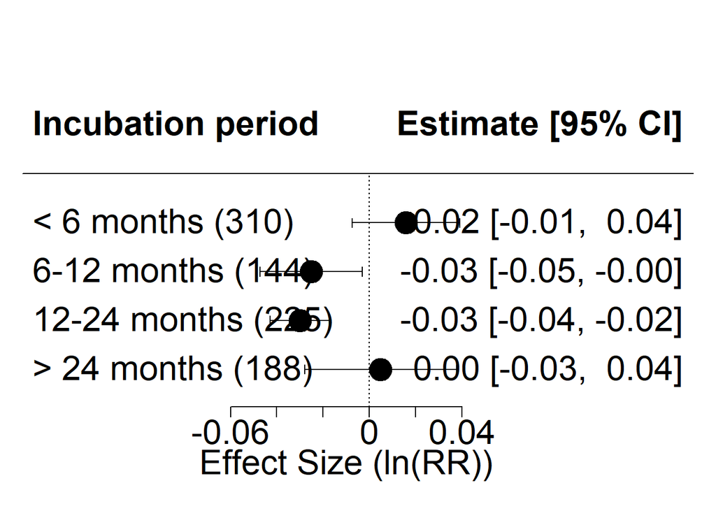

```r
estimates <- c(coef(six_months), coef(one_year), coef(two_years),coef(above_two_years))
variances <- c(vcov(six_months), vcov(one_year), vcov(two_years),vcov(above_two_years))
labels <- c("< 6 months (310)", "6-12 months (144)", "12-24 months (225)","> 24 months (188)")
forest(estimates, variances, slab=labels,col= "black" ,header = "Incubation period",pch=19,cex=2,xlab = "Effect Size (ln(RR))",psize = 1.5)
```

Plot the above forest plot using ggplot2 (Figure S4)

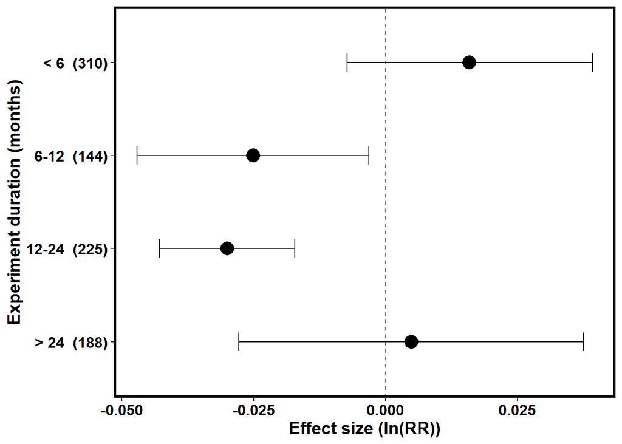

```r
dat5 <- data.frame(
  label = c("< 6  (310)", "6-12  (144)", "12-24  (225)","> 24  (188)"),
  point_est = c(0.0159 ,-0.0251, -0.0300 ,0.0049 ),
  lb_ci = c(-0.0073,-0.0471,-0.0429,-0.0278),
  ub_ci = c(0.0392 ,-0.0031,  -0.0172 , 0.0376))
dat5$label <- factor(dat5$label, levels = dat5$label)
plot5 <- ggplot(dat5, aes(x=point_est, y=label)) +
  geom_point(size=5) + scale_y_discrete(limits = rev(levels(dat5$label))) + geom_vline(xintercept=0, color="black", linetype="dashed", alpha=.5) +
  geom_errorbarh(aes(xmin=lb_ci, xmax=ub_ci), height=.2) +
  ylab("Experiment duration (months)") + xlab("Effect size (ln(RR))") + theme(text = element_text(size = 14,face="bold"), panel.background = element_blank(),
                                                   panel.grid.major = element_blank(),
                                                   panel.grid.minor = element_blank(),
                                                   axis.line = element_line(colour = "black"),
                                                   panel.border = element_rect(colour = "black", fill=NA, size=1.5)) +  theme(axis.text = element_text(family = "palatino", colour = "black", size = (12)))

plot5
```

#### 2.6.1.4 Estimated effect size based on litter species richness levels

```r
two_species<- rma(yi, vi, data = litmeta, subset = (species_richness == "two"))
three_species<- rma(yi, vi, data = litmeta, subset = (species_richness == "three"))
four_species <- rma(yi, vi, data = litmeta, subset = (species_richness == "four"))
five_species<- rma(yi, vi, data = litmeta, subset = (species_richness == "five"))
six_species <- rma(yi, vi, data = litmeta, subset = (species_richness == "six"))
twelve_species <- rma(yi, vi, data = litmeta, subset = (species_richness == "twelve"))
two_species
three_species
four_species
five_species
six_species
twelve_species
```

```
##
## Random-Effects Model (k = 609; tau^2 estimator: REML)
##
## tau^2 (estimated amount of total heterogeneity): 0.0214 (SE = 0.0017)
## tau (square root of estimated tau^2 value):      0.1464
## I^2 (total heterogeneity / total variability):   100.00%
## H^2 (total variability / sampling variability):  25152.10
##
## Test for Heterogeneity:
## Q(df = 608) = 24002805.7612, p-val < .0001
##
## Model Results:
##
## estimate      se    zval    pval    ci.lb   ci.ub
##   0.0023  0.0076  0.3004  0.7639  -0.0126  0.0171
##
## ---
## Signif. codes:  0 '***' 0.001 '**' 0.01 '*' 0.05 '.' 0.1 ' ' 1
##
##
## Random-Effects Model (k = 127; tau^2 estimator: REML)
##
## tau^2 (estimated amount of total heterogeneity): 0.0272 (SE = 0.0041)
## tau (square root of estimated tau^2 value):      0.1649
## I^2 (total heterogeneity / total variability):   100.00%
## H^2 (total variability / sampling variability):  131223.60
##
## Test for Heterogeneity:
## Q(df = 126) = 26920463.9355, p-val < .0001
##
## Model Results:
##
## estimate      se     zval    pval    ci.lb    ci.ub
##  -0.0361  0.0164  -2.2045  0.0275  -0.0682  -0.0040  *
##
## ---
## Signif. codes:  0 '***' 0.001 '**' 0.01 '*' 0.05 '.' 0.1 ' ' 1
##
##
## Random-Effects Model (k = 43; tau^2 estimator: REML)
```

[output cut: 58 more lines]

```
## tau^2 (estimated amount of total heterogeneity): 0 (SE = 0.0873)
## tau (square root of estimated tau^2 value):      0
## I^2 (total heterogeneity / total variability):   0.00%
## H^2 (total variability / sampling variability):  1.00
##
## Test for Heterogeneity:
## Q(df = 3) = 1.5633, p-val = 0.6677
##
## Model Results:
##
## estimate      se    zval    pval    ci.lb   ci.ub
##   0.2516  0.1649  1.5257  0.1271  -0.0716  0.5748
##
## ---
## Signif. codes:  0 '***' 0.001 '**' 0.01 '*' 0.05 '.' 0.1 ' ' 1
```

##### 2.6.1.4.1 Forest plot

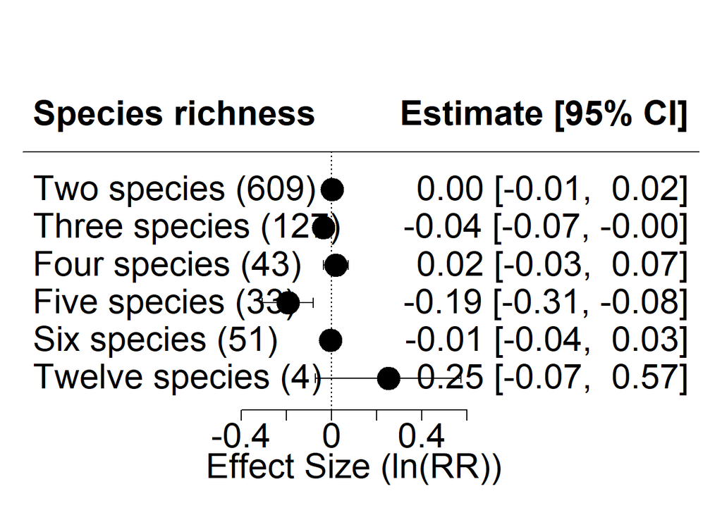

```r
estimates <- c(coef(two_species), coef(three_species), coef(four_species),coef(five_species), coef(six_species), coef(twelve_species))
variances <- c(vcov(two_species), vcov(three_species), vcov(four_species),vcov(five_species),vcov(six_species),vcov(twelve_species))
labels <- c("Two species (609)", "Three species (127)", "Four species (43)","Five species (33)","Six species (51)","Twelve species (4)")
forest(estimates, variances, slab=labels,col= "black" ,header = "Species richness",pch=19,cex=2,xlab = "Effect Size (ln(RR))",psize = 1.5)
```

Plot the above forest plot using ggplot2 (Figure S2 a)

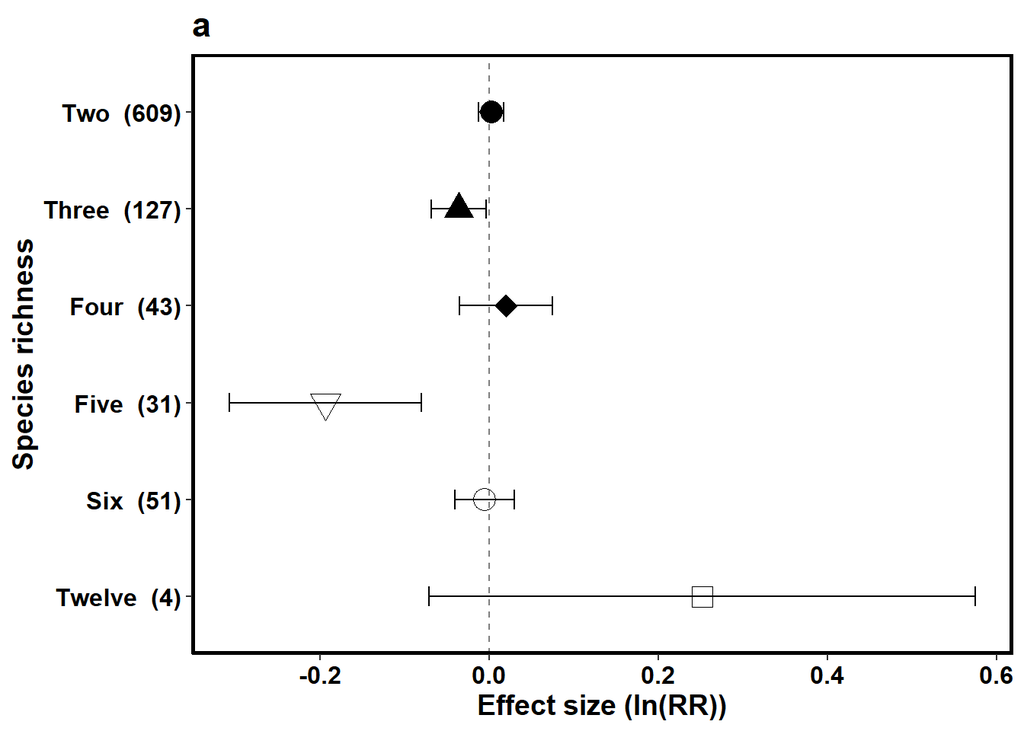

```r
dat3 <- data.frame(
  label = c("Two  (609)", "Three  (127)", "Four  (43)","Five  (31)", "Six  (51)", "Twelve  (4)"),
  point_est = c(0.0023 , -0.0361 ,  0.0200,-0.1938  ,  -0.0054,0.2516 ),
  lb_ci = c(-0.0126,-0.0682 , -0.0348,-0.3077,  -0.0407,-0.0716 ),
  ub_ci = c(0.0171,-0.0040,  0.0749 ,-0.0799, 0.0298, 0.5748),
  group = c(2,3,4,5,6,12)
)
dat3$label <- factor(dat3$label, levels = dat3$label)
plot3 <- ggplot(dat3, aes(x=point_est, y=label, shape=as.factor(group))) +
  scale_shape_manual(values = c(16, 17,18,25,21,22))+ theme(legend.position="none") +
  geom_point(size=5) + scale_y_discrete(limits = rev(levels(dat3$label))) + geom_vline(xintercept=0, color="black", linetype="dashed", alpha=.5) +
  geom_errorbarh(aes(xmin=lb_ci, xmax=ub_ci), height=.2) +
  ggtitle("a")+
  ylab("Species richness") + xlab("Effect size (ln(RR))") + theme(text = element_text(size = 14,face="bold"), panel.background = element_blank(),
                                                   panel.grid.major = element_blank(),
                                                   panel.grid.minor = element_blank(),
                                                   axis.line = element_line(colour = "black"),
                                                   panel.border = element_rect(colour = "black", fill=NA, size=1.5)) +  theme(axis.text = element_text(family = "palatino", colour = "black", size = (12)))
plot3
```

#### 2.6.1.5 Estimated effect size based on the precipitation levels

```r
pl<-rma(yi, vi, data = litmeta, subset = (precipitation_levels=="low"))
pm<-rma(yi, vi, data = litmeta, subset = (precipitation_levels=="medium"))
ph<-rma(yi, vi, data = litmeta, subset = (precipitation_levels=="high"))
summary(pl)
summary(pm)
summary(ph)
```

```
##
## Random-Effects Model (k = 486; tau^2 estimator: REML)
##
##   logLik  deviance       AIC       BIC      AICc
##  12.6223  -25.2447  -21.2447  -12.8764  -21.2198
##
## tau^2 (estimated amount of total heterogeneity): 0.0266 (SE = 0.0025)
## tau (square root of estimated tau^2 value):      0.1631
## I^2 (total heterogeneity / total variability):   100.00%
## H^2 (total variability / sampling variability):  89218.26
##
## Test for Heterogeneity:
## Q(df = 485) = 34405357.8981, p-val < .0001
##
## Model Results:
##
## estimate      se     zval    pval    ci.lb   ci.ub
##  -0.0077  0.0095  -0.8115  0.4171  -0.0264  0.0110
##
## ---
## Signif. codes:  0 '***' 0.001 '**' 0.01 '*' 0.05 '.' 0.1 ' ' 1
##
##
## Random-Effects Model (k = 287; tau^2 estimator: REML)
##
##   logLik  deviance       AIC       BIC      AICc
##  26.5194  -53.0388  -49.0388  -41.7268  -48.9964
##
## tau^2 (estimated amount of total heterogeneity): 0.0166 (SE = 0.0020)
## tau (square root of estimated tau^2 value):      0.1288
## I^2 (total heterogeneity / total variability):   99.79%
## H^2 (total variability / sampling variability):  476.57
##
## Test for Heterogeneity:
## Q(df = 286) = 43504.5258, p-val < .0001
##
## Model Results:
##
## estimate      se     zval    pval    ci.lb   ci.ub
##  -0.0177  0.0099  -1.7908  0.0733  -0.0371  0.0017  .
```

[output cut: 10 more lines]

```
## tau^2 (estimated amount of total heterogeneity): 0.0170 (SE = 0.0030)
## tau (square root of estimated tau^2 value):      0.1304
## I^2 (total heterogeneity / total variability):   99.98%
## H^2 (total variability / sampling variability):  4273.24
##
## Test for Heterogeneity:
## Q(df = 93) = 959340.7319, p-val < .0001
##
## Model Results:
##
## estimate      se    zval    pval    ci.lb   ci.ub
##   0.0198  0.0148  1.3310  0.1832  -0.0093  0.0489
##
## ---
## Signif. codes:  0 '***' 0.001 '**' 0.01 '*' 0.05 '.' 0.1 ' ' 1
```

##### 2.6.1.5.1 Forest plot

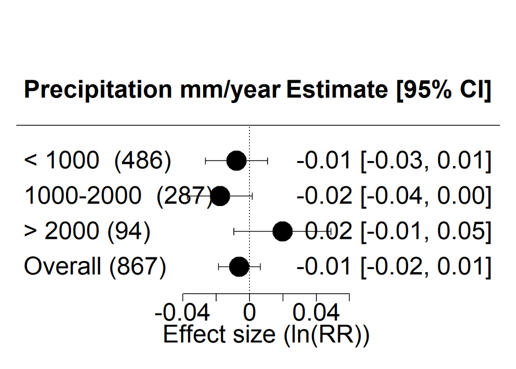

```r
estimates <- c(coef(pl), coef(pm), coef(ph),coef(random_m))
variances <- c(vcov(pl), vcov(pm), vcov(ph), vcov(random_m))
labels <- c("< 1000  (486)", "1000-2000  (287)", "> 2000 (94)","Overall (867)")
forest(estimates, variances, slab=labels,header = "Precipitation mm/year ",col="black",xlab="Effect size (ln(RR))",pch=19, cex=2, psize = 1.8)
```

#### 2.6.2.1 Create new data sets

```r
low_precipt<- litmeta[litmeta$precipitation_levels == "low", ]
high_precipt<- litmeta[litmeta$precipitation_levels == "high", ]
medium_precipt<- litmeta[litmeta$precipitation_levels == "medium", ]
dim(low_precipt)
dim(medium_precipt)
dim(high_precipt)
low_precipt2<- low_precipt[low_precipt$Fauna_available == "present", ]
high_precipt2<- high_precipt[high_precipt$Fauna_available == "present", ]
medium_precipt2<- medium_precipt[medium_precipt$Fauna_available == "present", ]

dim(low_precipt2)
dim(high_precipt2)
dim(medium_precipt2)
```

#### 2.6.2.2 Calculate the estimate for each new data set

We used random effect model to do so.

##### 2.6.2.2.1 Low precipitation

```r
rlp <- rma(yi = yi, vi = vi, method = "REML", data = low_precipt)
summary(rlp)
```

```
##
## Random-Effects Model (k = 486; tau^2 estimator: REML)
##
##   logLik  deviance       AIC       BIC      AICc
##  12.6223  -25.2447  -21.2447  -12.8764  -21.2198
##
## tau^2 (estimated amount of total heterogeneity): 0.0266 (SE = 0.0025)
## tau (square root of estimated tau^2 value):      0.1631
## I^2 (total heterogeneity / total variability):   100.00%
## H^2 (total variability / sampling variability):  89218.26
##
## Test for Heterogeneity:
## Q(df = 485) = 34405357.8981, p-val < .0001
##
## Model Results:
##
## estimate      se     zval    pval    ci.lb   ci.ub
##  -0.0077  0.0095  -0.8115  0.4171  -0.0264  0.0110
##
## ---
## Signif. codes:  0 '***' 0.001 '**' 0.01 '*' 0.05 '.' 0.1 ' ' 1
```

##### 2.6.2.2.2 Medium precipitation

```r
rmep <- rma(yi = yi, vi = vi, method = "REML", data = medium_precipt)
summary(rmep)
```

```
##
## Random-Effects Model (k = 287; tau^2 estimator: REML)
##
##   logLik  deviance       AIC       BIC      AICc
##  26.5194  -53.0388  -49.0388  -41.7268  -48.9964
##
## tau^2 (estimated amount of total heterogeneity): 0.0166 (SE = 0.0020)
## tau (square root of estimated tau^2 value):      0.1288
## I^2 (total heterogeneity / total variability):   99.79%
## H^2 (total variability / sampling variability):  476.57
##
## Test for Heterogeneity:
## Q(df = 286) = 43504.5258, p-val < .0001
##
## Model Results:
##
## estimate      se     zval    pval    ci.lb   ci.ub
##  -0.0177  0.0099  -1.7908  0.0733  -0.0371  0.0017  .
##
## ---
## Signif. codes:  0 '***' 0.001 '**' 0.01 '*' 0.05 '.' 0.1 ' ' 1
```

##### 2.6.2.2.3 High precipitation

```r
rhi <- rma(yi = yi, vi = vi, method = "REML", data = high_precipt)
summary(rhi)
```

```
##
## Random-Effects Model (k = 94; tau^2 estimator: REML)
##
##   logLik  deviance       AIC       BIC      AICc
##  49.7143  -99.4286  -95.4286  -90.3634  -95.2953
##
## tau^2 (estimated amount of total heterogeneity): 0.0170 (SE = 0.0030)
## tau (square root of estimated tau^2 value):      0.1304
## I^2 (total heterogeneity / total variability):   99.98%
## H^2 (total variability / sampling variability):  4273.24
##
## Test for Heterogeneity:
## Q(df = 93) = 959340.7319, p-val < .0001
##
## Model Results:
##
## estimate      se    zval    pval    ci.lb   ci.ub
##   0.0198  0.0148  1.3310  0.1832  -0.0093  0.0489
##
## ---
## Signif. codes:  0 '***' 0.001 '**' 0.01 '*' 0.05 '.' 0.1 ' ' 1
```

#### 2.6.2.3 Meta regression on each data set

we performed a meta-regression using fauna as the main moderator for each data. This is to see how fauna effect changes with the precipitation levels.

##### 2.6.2.3.1 Estimate of effect size

```r
mhip<- rma (yi = yi, vi = vi, mod = ~Fauna_available, method = "REML", data = high_precipt )
mmep<- rma (yi = yi, vi = vi, mod = ~Fauna_available, method = "REML", data = medium_precipt )
mlop<- rma (yi = yi, vi = vi, mod = ~Fauna_available, method = "REML", data = low_precipt)
summary (mhip)
summary (mmep)
summary (mlop)
```

```
##
## Mixed-Effects Model (k = 94; tau^2 estimator: REML)
##
##   logLik  deviance       AIC       BIC      AICc
##  49.1350  -98.2700  -92.2700  -84.7046  -91.9972
##
## tau^2 (estimated amount of residual heterogeneity):     0.0170 (SE = 0.0030)
## tau (square root of estimated tau^2 value):             0.1305
## I^2 (residual heterogeneity / unaccounted variability): 99.97%
## H^2 (unaccounted variability / sampling variability):   3060.48
## R^2 (amount of heterogeneity accounted for):            0.00%
##
## Test for Residual Heterogeneity:
## QE(df = 92) = 865775.0752, p-val < .0001
##
## Test of Moderators (coefficient 2):
## QM(df = 1) = 0.8868, p-val = 0.3464
##
## Model Results:
##
##                         estimate      se     zval    pval    ci.lb   ci.ub
## intrcpt                   0.0351  0.0220   1.5922  0.1113  -0.0081  0.0783
## Fauna_availablepresent   -0.0281  0.0298  -0.9417  0.3464  -0.0866  0.0304
##
## ---
## Signif. codes:  0 '***' 0.001 '**' 0.01 '*' 0.05 '.' 0.1 ' ' 1
##
##
## Mixed-Effects Model (k = 287; tau^2 estimator: REML)
##
##   logLik  deviance       AIC       BIC      AICc
##  31.6948  -63.3896  -57.3896  -46.4321  -57.3042
##
## tau^2 (estimated amount of residual heterogeneity):     0.0161 (SE = 0.0020)
## tau (square root of estimated tau^2 value):             0.1267
## I^2 (residual heterogeneity / unaccounted variability): 99.78%
## H^2 (unaccounted variability / sampling variability):   452.73
## R^2 (amount of heterogeneity accounted for):            3.24%
##
## Test for Residual Heterogeneity:
```

[output cut: 31 more lines]

```
##
## Test of Moderators (coefficient 2):
## QM(df = 1) = 23.9528, p-val < .0001
##
## Model Results:
##
##                         estimate      se     zval    pval    ci.lb    ci.ub
## intrcpt                  -0.0408  0.0116  -3.5200  0.0004  -0.0635  -0.0181
## Fauna_availablepresent    0.0951  0.0194   4.8942  <.0001   0.0570   0.1332
##
## intrcpt                 ***
## Fauna_availablepresent  ***
##
## ---
## Signif. codes:  0 '***' 0.001 '**' 0.01 '*' 0.05 '.' 0.1 ' ' 1
```

From the metaregression results as the precipitation reduces the impact of soil fauna availability on the overall effect size increases.

##### 2.6.2.3.2 Fauna effect on different precipitation levels

```r
lowpre_fauna<-rma(yi, vi, data = low_precipt, subset = (Fauna_available=="present"))
lowpre_none<-rma(yi, vi, data = low_precipt, subset = (Fauna_available=="absent"))
mepre_fauna<-rma(yi, vi, data = medium_precipt, subset = (Fauna_available=="present"))
mepre_none<-rma(yi, vi, data = medium_precipt, subset = (Fauna_available=="absent"))
hipre_fauna<-rma(yi, vi, data = high_precipt, subset = (Fauna_available=="present"))
hipre_none<-rma(yi, vi, data = high_precipt, subset = (Fauna_available=="absent"))
lowpre_fauna
mepre_fauna
hipre_fauna
lowpre_none
mepre_none
hipre_none
```

```
##
## Random-Effects Model (k = 140; tau^2 estimator: REML)
##
## tau^2 (estimated amount of total heterogeneity): 0.0553 (SE = 0.0078)
## tau (square root of estimated tau^2 value):      0.2351
## I^2 (total heterogeneity / total variability):   100.00%
## H^2 (total variability / sampling variability):  645655.67
##
## Test for Heterogeneity:
## Q(df = 139) = 32894186.1146, p-val < .0001
##
## Model Results:
##
## estimate      se    zval    pval   ci.lb   ci.ub
##   0.0480  0.0218  2.2006  0.0278  0.0052  0.0907  *
##
## ---
## Signif. codes:  0 '***' 0.001 '**' 0.01 '*' 0.05 '.' 0.1 ' ' 1
##
##
## Random-Effects Model (k = 81; tau^2 estimator: REML)
##
## tau^2 (estimated amount of total heterogeneity): 0.0481 (SE = 0.0085)
## tau (square root of estimated tau^2 value):      0.2193
## I^2 (total heterogeneity / total variability):   99.73%
## H^2 (total variability / sampling variability):  371.25
##
## Test for Heterogeneity:
## Q(df = 80) = 7443.0820, p-val < .0001
##
## Model Results:
##
## estimate      se    zval    pval    ci.lb   ci.ub
##   0.0414  0.0262  1.5779  0.1146  -0.0100  0.0929
##
## ---
## Signif. codes:  0 '***' 0.001 '**' 0.01 '*' 0.05 '.' 0.1 ' ' 1
##
##
## Random-Effects Model (k = 53; tau^2 estimator: REML)
```

[output cut: 58 more lines]

```
## tau^2 (estimated amount of total heterogeneity): 0.0051 (SE = 0.0015)
## tau (square root of estimated tau^2 value):      0.0713
## I^2 (total heterogeneity / total variability):   98.19%
## H^2 (total variability / sampling variability):  55.29
##
## Test for Heterogeneity:
## Q(df = 40) = 686.9609, p-val < .0001
##
## Model Results:
##
## estimate      se    zval    pval   ci.lb   ci.ub
##   0.0385  0.0133  2.8853  0.0039  0.0123  0.0646  **
##
## ---
## Signif. codes:  0 '***' 0.001 '**' 0.01 '*' 0.05 '.' 0.1 ' ' 1
```

##### 2.6.2.3.3 Forest plot

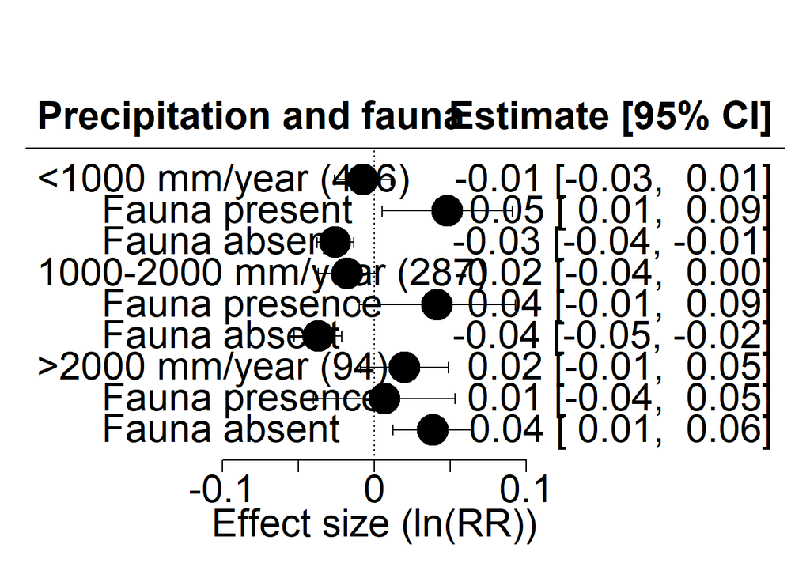

```r
estimates <- c(coef(pl), coef(lowpre_fauna),coef(lowpre_none),coef(pm),coef(mepre_fauna),coef(mepre_none), coef(ph),coef(hipre_fauna),coef(hipre_none))
variances <- c(vcov(pl), vcov(lowpre_fauna),vcov(lowpre_none),vcov(pm),vcov(mepre_fauna),vcov(mepre_none),vcov(ph),vcov(hipre_fauna),vcov(hipre_none))
labels <- c("<1000 mm/year (486)","      Fauna present","      Fauna absent", "1000-2000 mm/year (287)","      Fauna presence", "      Fauna absent",">2000 mm/year (94)","      Fauna presence","      Fauna absent")
forest(estimates, variances, slab=labels,header = "Precipitation and fauna",xlab = "Effect size (ln(RR))", cex=2,pch = 19, psize=1.8)
```

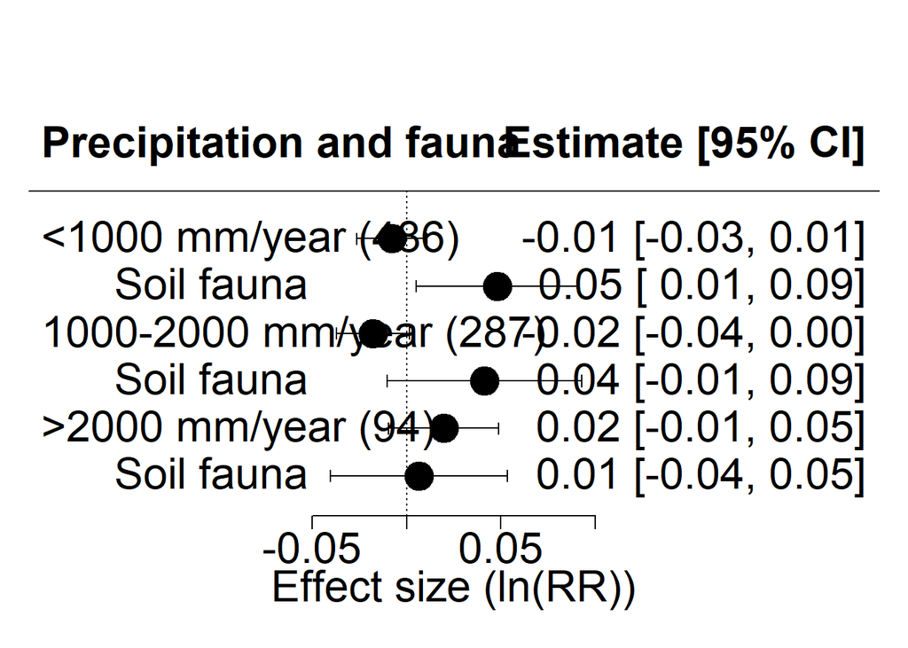

```r
estimates <- c(coef(pl), coef(lowpre_fauna),coef(pm),coef(mepre_fauna), coef(ph),coef(hipre_fauna))
variances <- c(vcov(pl), vcov(lowpre_fauna),vcov(pm),vcov(mepre_fauna), vcov(ph),vcov(hipre_fauna))
labels <- c("<1000 mm/year (486)","      Soil fauna", "1000-2000 mm/year (287)","      Soil fauna", ">2000 mm/year (94)","      Soil fauna")
forest(estimates, variances, slab=labels,header = "Precipitation and fauna",xlab = "Effect size (ln(RR))", cex=2,pch = 19, psize=1.5)
```

Plot precipitation and fauna with ggplot2 (Figure 4 a).

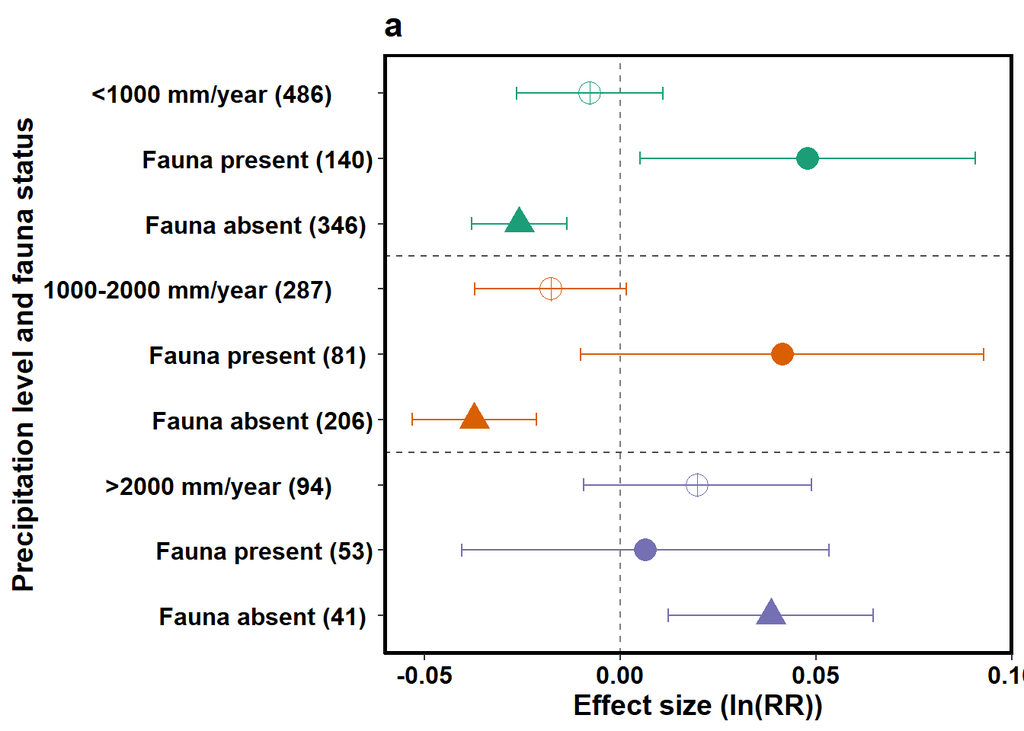

```
## [1] 1 2 3 1 2 3 1 2 3
## Levels: 1 2 3
```

```r
dat6 <- data.frame(
  label = c("<1000 mm/year (486)      ","Fauna present (140)", "Fauna absent (346) ","1000-2000 mm/year (287)      ","Fauna present (81) ",
            "Fauna absent (206)", ">2000 mm/year (94)      ","Fauna present (53)","Fauna absent (41) "),
  point_est = c(-0.0077,0.0480,-0.0257, -0.0177,0.0414,-0.0372, 0.0198  , 0.0065,0.0385),
  lb_ci = c(-0.0264,0.0052,-0.0379, -0.0371,-0.0100, -0.0530, -0.0093,-0.0403,0.0123),
  ub_ci = c(0.0110,0.0907,  -0.0135, 0.0017, 0.0929,-0.0213, 0.0489, 0.0533,0.0646 ),
  group = c(1,2,3,1,2,3,1,2,3),
  precip_level= c(1,1,1,2,2,2,3,3,3)
)
dat6$label <- factor(dat6$label, levels = dat6$label)
as.factor(dat6$group)
plot6 <- ggplot(dat6, aes(x=point_est, y=label, shape=as.factor(group),color=as.factor(precip_level))) + scale_shape_manual(values = c(10, 16, 17))+
  scale_color_brewer(palette="Dark2")+
  geom_hline(yintercept = c(3.5,6.5),color="black", linetype="dashed", alpha=.7)+
  theme(legend.position="none") +
  geom_point(size=5) + scale_y_discrete(limits = rev(levels(dat6$label))) + geom_vline(xintercept=0, color="black", linetype="dashed", alpha=.5) +
  geom_errorbarh(aes(xmin=lb_ci, xmax=ub_ci), height=.2) +
  ggtitle("a")+
  ylab("Precipitation level and fauna status") + xlab("Effect size (ln(RR))") + theme(text = element_text(size = 14,face="bold"), panel.background = element_blank(),
                                                   panel.grid.major = element_blank(),
                                                   panel.grid.minor = element_blank(),
                                                   axis.line = element_line(colour = "black"),
                                                   panel.border = element_rect(colour = "black", fill=NA, size=1.5)) +  theme(axis.text = element_text(family = "palatino", colour = "black", size = (12)))
plot6
```

visualize the relationship between soil fauna status and annual precipitation in mm Only the fauna status that shows significant effect is shown. This the Figure S3 in the supplementary material.

Using ggplot to visualize the relationship between soil fauna and precipitation. we only show the linear regression when its positive.

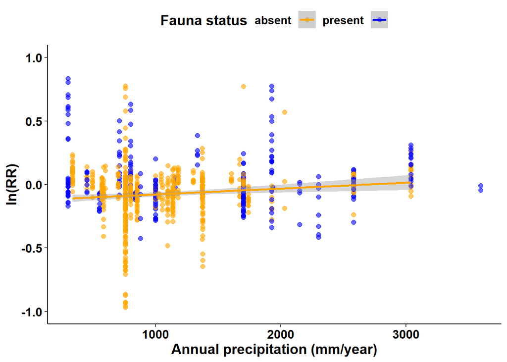

```r
faunaprecipitation<- ggplot(litmeta) +
  aes(x = Annual_precip, y = yi, color = Fauna_available) + scale_y_continuous(limits = c(-1, 1))+
  geom_point(size= 2, alpha=0.6) + scale_color_manual(values = c("absent" = "orange","present" = "blue")) +
                                                             geom_smooth(method = "lm", data=subset(litmeta,Fauna_available=="absent"))+ ylab("ln(RR)") +
  xlab("Annual precipitation (mm/year)") +
  theme(text = element_text(size = 14,face="bold"), panel.background = element_blank(),panel.grid.major = element_blank(),
  panel.grid.minor = element_blank(),legend.position = "top",
  axis.line = element_line(colour = "black")) + labs(color = "Fauna status")+
  theme(axis.text = element_text(family = "palatino", colour = "black", size = (12))) + guides(colour = guide_legend(label.position = "left", label.hjust = 1))

faunaprecipitation
```

See the relationship of fauna status and incubation period (Figure S5).

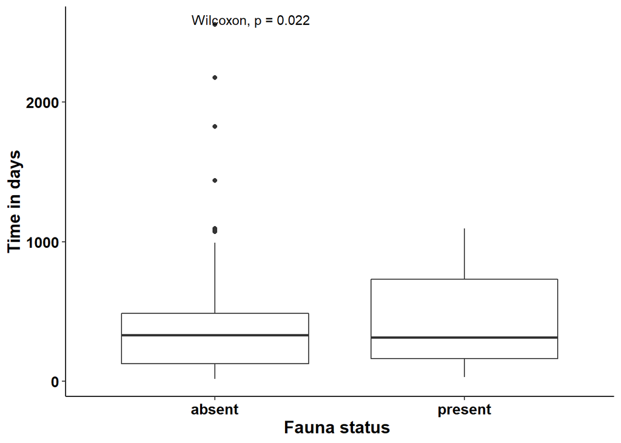

```r
library(ggpubr)
boxfauna<- ggplot(litmeta, aes(y=Time_Days, x=Fauna_available)) +
  geom_boxplot()+ylab("Time in days") +
  xlab("Fauna status ") + stat_compare_means(paired = FALSE)+
  theme(text = element_text(size = 14,face="bold"), panel.background = element_blank(),panel.grid.major = element_blank(),
        panel.grid.minor = element_blank(),legend.position = "top",
        axis.line = element_line(colour = "black")) + labs(color = "Fauna status")+
  theme(axis.text = element_text(family = "palatino", colour = "black", size = (12))) + guides(colour = guide_legend(label.position = "left", label.hjust = 1))
boxfauna
```

```r
path<- getwd()
ggsave(filename="fig s5.png", plot=boxfauna, device="png",
       path=path, height=5, width=5, units="in", dpi=300)
```

### 2.6.3 Effect size for fauna inclusion by climatic region

We did a metaregression showing how availability of fauna affects the effect sizes by climatic region here we create new data frame based on the climatic region

#### 2.6.3.1 Create new data set

```r
tropics<- litmeta[litmeta$climatic_region == "Tropics", ]
subtropics<- litmeta[litmeta$climatic_region == "Sub-tropics", ]
temperate<- litmeta[litmeta$climatic_region == "Temperate", ]
dim(tropics)
dim(subtropics)
dim(temperate)
```

```
## [1] 120  56
## [1] 243  56
## [1] 504  56
```

#### 2.6.3.2 Random effect models

Here we do a random effect model for each climatic region.

```r
#tropical regions
trop <- rma(yi = yi, vi = vi, method = "REML", data = tropics)
summary(trop)
#subtropic regions
sub <- rma(yi = yi, vi = vi, method = "REML", data = subtropics)
summary(sub)
#temperate region
temp <- rma(yi = yi, vi = vi, method = "REML", data = temperate)
summary(temp)
```

```
##
## Random-Effects Model (k = 120; tau^2 estimator: REML)
##
##   logLik  deviance       AIC       BIC      AICc
##  -0.2995    0.5991    4.5991   10.1573    4.7025
##
## tau^2 (estimated amount of total heterogeneity): 0.0340 (SE = 0.0049)
## tau (square root of estimated tau^2 value):      0.1845
## I^2 (total heterogeneity / total variability):   99.89%
## H^2 (total variability / sampling variability):  871.73
##
## Test for Heterogeneity:
## Q(df = 119) = 9309.8100, p-val < .0001
##
## Model Results:
##
## estimate      se    zval    pval   ci.lb   ci.ub
##   0.0523  0.0181  2.8910  0.0038  0.0168  0.0878  **
##
## ---
## Signif. codes:  0 '***' 0.001 '**' 0.01 '*' 0.05 '.' 0.1 ' ' 1
##
##
## Random-Effects Model (k = 243; tau^2 estimator: REML)
##
##   logLik  deviance       AIC       BIC      AICc
## -22.8779   45.7558   49.7558   56.7336   49.8060
##
## tau^2 (estimated amount of total heterogeneity): 0.0392 (SE = 0.0051)
## tau (square root of estimated tau^2 value):      0.1979
## I^2 (total heterogeneity / total variability):   100.00%
## H^2 (total variability / sampling variability):  264013.61
##
## Test for Heterogeneity:
## Q(df = 242) = 35964103.8952, p-val < .0001
##
## Model Results:
##
## estimate      se    zval    pval    ci.lb   ci.ub
##   0.0193  0.0161  1.1939  0.2325  -0.0124  0.0509
```

[output cut: 10 more lines]

```
## tau^2 (estimated amount of total heterogeneity): 0.0078 (SE = 0.0008)
## tau (square root of estimated tau^2 value):      0.0881
## I^2 (total heterogeneity / total variability):   99.69%
## H^2 (total variability / sampling variability):  321.03
##
## Test for Heterogeneity:
## Q(df = 503) = 904792.7749, p-val < .0001
##
## Model Results:
##
## estimate      se     zval    pval    ci.lb    ci.ub
##  -0.0359  0.0056  -6.3569  <.0001  -0.0469  -0.0248  ***
##
## ---
## Signif. codes:  0 '***' 0.001 '**' 0.01 '*' 0.05 '.' 0.1 ' ' 1
```

```r
metrop<- rma (yi = yi, vi = vi, mod = ~Fauna_available, method = "REML", data = tropics )
metsub<- rma (yi = yi, vi = vi, mod = ~Fauna_available, method = "REML", data = subtropics )
mettemp<- rma (yi = yi, vi = vi, mod = ~Fauna_available, method = "REML", data = temperate)
summary(metrop)
summary(metsub)
summary(mettemp)
```

```
##
## Mixed-Effects Model (k = 120; tau^2 estimator: REML)
##
##   logLik  deviance       AIC       BIC      AICc
##  -1.0309    2.0619    8.0619   16.3739    8.2724
##
## tau^2 (estimated amount of residual heterogeneity):     0.0345 (SE = 0.0050)
## tau (square root of estimated tau^2 value):             0.1858
## I^2 (residual heterogeneity / unaccounted variability): 99.83%
## H^2 (unaccounted variability / sampling variability):   584.36
## R^2 (amount of heterogeneity accounted for):            0.00%
##
## Test for Residual Heterogeneity:
## QE(df = 118) = 9024.2625, p-val < .0001
##
## Test of Moderators (coefficient 2):
## QM(df = 1) = 0.0002, p-val = 0.9880
##
## Model Results:
##
##                         estimate      se     zval    pval    ci.lb   ci.ub
## intrcpt                   0.0530  0.0397   1.3341  0.1822  -0.0248  0.1307
## Fauna_availablepresent   -0.0007  0.0447  -0.0151  0.9880  -0.0882  0.0869
##
## ---
## Signif. codes:  0 '***' 0.001 '**' 0.01 '*' 0.05 '.' 0.1 ' ' 1
##
##
## Mixed-Effects Model (k = 243; tau^2 estimator: REML)
##
##   logLik  deviance       AIC       BIC      AICc
##   6.4286  -12.8573   -6.8573    3.5971   -6.7560
##
## tau^2 (estimated amount of residual heterogeneity):     0.0276 (SE = 0.0038)
## tau (square root of estimated tau^2 value):             0.1661
## I^2 (residual heterogeneity / unaccounted variability): 100.00%
## H^2 (unaccounted variability / sampling variability):   186500.48
## R^2 (amount of heterogeneity accounted for):            29.57%
##
## Test for Residual Heterogeneity:
```

[output cut: 31 more lines]

```
##
## Test of Moderators (coefficient 2):
## QM(df = 1) = 8.6998, p-val = 0.0032
##
## Model Results:
##
##                         estimate      se     zval    pval    ci.lb    ci.ub
## intrcpt                  -0.0261  0.0064  -4.0790  <.0001  -0.0386  -0.0136
## Fauna_availablepresent   -0.0369  0.0125  -2.9495  0.0032  -0.0615  -0.0124
##
## intrcpt                 ***
## Fauna_availablepresent   **
##
## ---
## Signif. codes:  0 '***' 0.001 '**' 0.01 '*' 0.05 '.' 0.1 ' ' 1
```

#### 2.6.3.3 Effect sizes based on the fauna status in different climatic regions

```r
tr_fauna<-rma(yi, vi, data = tropics, subset = (Fauna_available=="present"))
sub_fauna<-rma(yi, vi, data = subtropics, subset = (Fauna_available=="present"))
temp_fauna<-rma(yi, vi, data = temperate, subset = (Fauna_available=="present"))
tr_fauna
sub_fauna
temp_fauna
tr_fauna_none<-rma(yi, vi, data = tropics, subset = (Fauna_available=="absent"))
sub_fauna_none<-rma(yi, vi, data = subtropics, subset = (Fauna_available=="absent"))
temp_fauna_none<-rma(yi, vi, data = temperate, subset = (Fauna_available=="absent"))
tr_fauna_none
sub_fauna_none
temp_fauna_none
```

```
##
## Random-Effects Model (k = 97; tau^2 estimator: REML)
##
## tau^2 (estimated amount of total heterogeneity): 0.0438 (SE = 0.0071)
## tau (square root of estimated tau^2 value):      0.2094
## I^2 (total heterogeneity / total variability):   99.79%
## H^2 (total variability / sampling variability):  482.44
##
## Test for Heterogeneity:
## Q(df = 96) = 8333.2660, p-val < .0001
##
## Model Results:
##
## estimate      se    zval    pval   ci.lb   ci.ub
##   0.0548  0.0229  2.3961  0.0166  0.0100  0.0996  *
##
## ---
## Signif. codes:  0 '***' 0.001 '**' 0.01 '*' 0.05 '.' 0.1 ' ' 1
##
##
## Random-Effects Model (k = 50; tau^2 estimator: REML)
##
## tau^2 (estimated amount of total heterogeneity): 0.0761 (SE = 0.0163)
## tau (square root of estimated tau^2 value):      0.2758
## I^2 (total heterogeneity / total variability):   100.00%
## H^2 (total variability / sampling variability):  2519399.95
##
## Test for Heterogeneity:
## Q(df = 49) = 32867448.2532, p-val < .0001
##
## Model Results:
##
## estimate      se    zval    pval   ci.lb   ci.ub
##   0.1938  0.0404  4.8021  <.0001  0.1147  0.2729  ***
##
## ---
## Signif. codes:  0 '***' 0.001 '**' 0.01 '*' 0.05 '.' 0.1 ' ' 1
##
##
## Random-Effects Model (k = 127; tau^2 estimator: REML)
```

[output cut: 58 more lines]

```
## tau^2 (estimated amount of total heterogeneity): 0.0048 (SE = 0.0006)
## tau (square root of estimated tau^2 value):      0.0690
## I^2 (total heterogeneity / total variability):   97.70%
## H^2 (total variability / sampling variability):  43.41
##
## Test for Heterogeneity:
## Q(df = 376) = 4032.5220, p-val < .0001
##
## Model Results:
##
## estimate      se     zval    pval    ci.lb    ci.ub
##  -0.0239  0.0055  -4.3833  <.0001  -0.0346  -0.0132  ***
##
## ---
## Signif. codes:  0 '***' 0.001 '**' 0.01 '*' 0.05 '.' 0.1 ' ' 1
```